# 1 An introduction to linear statistical models

## 1.1 Statistical models

- A primary goal of statistical modelling is to characterise the relationship between variables, for now lets call them $X$ and $Y$.
- In this context, we designate one variable, $Y$ as the *outcome* or *dependent variable*, and attempt to construct a *model* describing how it depends on the other variable(s), $X$, which we call *predictors* or *independent variables*.
- We can express the idea that $Y$ depends on $X$ mathematically as
  $$Y=f(X)$$
- That is, $Y$ is some function of $X$ (we have not yet specified what kind of function). Given values of $X$, we can use this function to *predict* or *explain* corresponding values of $Y$.
- This is similar to *deterministic models* you may know from physics - for example
  $$E=MC^2$$
  , where $E$ (the outcome), depends on $M$ (a predictor) through the function $f(M)=MC^2$).
- In statistical modelling we take another step and assume that $Y$ is not a purely determinsitic function of $X$, but that it varies somewhat randomly around such a relationship. We capture this by introducing a *random error term* , $\varepsilon$:
  $$Y=f(X)+\varepsilon
  \tag{1.1}$$

Here $\varepsilon$ represents the random variation in $Y$ that is not explained by $X$.

- This means that $Y$ is not perfectly determined by $X$: even if we know the values of X, the outcome Y can still vary due to random noise.

**Assumption 1**

$Y$ depends only on a deterministic function of $X$ and a random noise component

## 1.2 Linear prediction

- We now choose $f(X)$ to be a *linear function*:

$$f(X)= \beta_0 + \beta_1\cdot X$$

- Putting aside the random error term for the moment, we can think of the *expected value* of $Y$, denoted $E[Y]$, as being given by this linear relationship:

$$E[Y]= \beta_0 + \beta_1\cdot X
\tag{1.2}$$

- In other words, we are representing the expected value of $Y$ as a *straight line* with y-intercept $\beta_0$ and slope $\beta_1$:

[interactive chart not shown]

(a)

[interactive chart not shown]

(b)

[interactive chart not shown]

(c)

Figure 1.1: Plot of the linear function E[Y] = β₀+ β₁X

- Here, $\beta_0$ represents the expected value of $Y$ ($E[Y]$) when $X=0$, and $\beta_1$ represents the change in $E[Y]$ for a one-unit increase in $X$.

**Assumption 2**

Y and X have a linear relationship

**Example 1:** Salary growth over time**

You’ve been offered a job at ~company A~, and want to predict your salary at this company after working there for 10 years. We know that, on average, the *starting salary* at this company is $50,000, and salaries increase by $5000 per year of employment.

Using this information, we can construct a simple linear predictor of salary from employment time. Given an employment time of $X=x$ years, we can represent a employee’s expected salary ($E[Y]$) as

$$E[Y]= \$50,000 + \$5,000\cdot x.$$

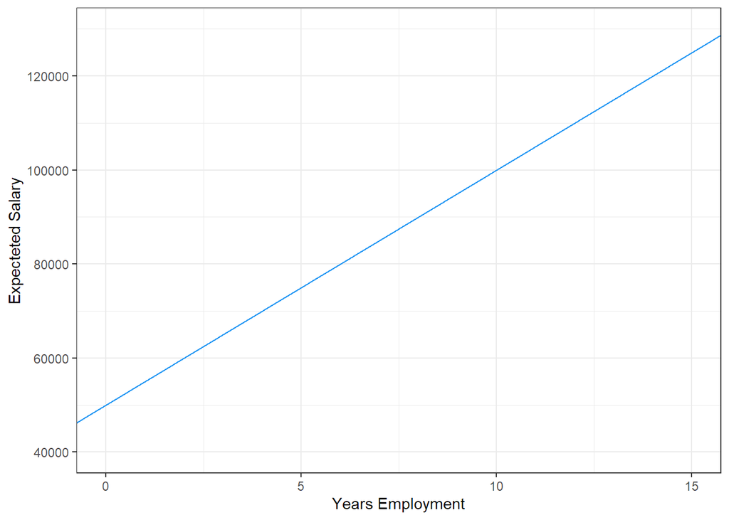

```r
ggplot()+
  aes()+
  geom_abline(intercept=5e4, slope=5e3, colour='#2196F3')+
  lims(x=c(0,15),y=c(4e4,13e4))+
  labs(x="Years Employment", y= "Expecteted Salary")
```

After 10 years of working at this company (i.e. $X=10$), we would expect a salary of
$$E[Y]=\$50,000 + \$5,000\times10= \$100,000$$

**Exercise 1:** A competing offer**

A second company also has a job available. The *starting salary* ishigher here - $70,000 on average - but payrises are smaller. You are told that, on average, employees working for the company for 6 years earn $18,000 more per year than when they started.

You want to use a simple linear prediction to calculate your expectedsalary ($E[Y]$) after $X$ years of employment.

$$E[Y] = \beta_0 + \beta_1 X$$

#### Choosing parameters

What are the coefficients $\beta_0$ and $\beta_1$ in this case?

Assign the relevant values to variables in R

#### Linear prediction

Great, so our linear predictor of the expected salary looks something like:
$$E[Y]= \$70,000 + \$3,000\cdot X$$

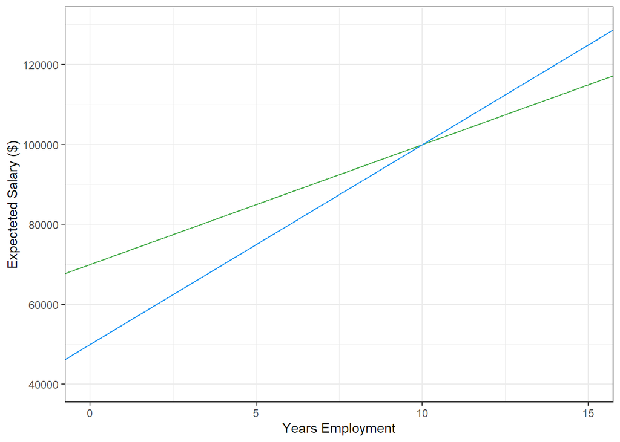

```r
ggplot()+
  aes()+
  geom_abline(intercept=7e4, slope=3e3, colour="#4CAF50")+
  geom_abline(intercept=5e4, slope=5e3, colour='#2196F3')+
  lims(x=c(0,15),y=c(4e4,13e4))+
  labs(x="Years Employment", y= "Expecteted Salary ($)")
```

Using the parameter variables you just defined, calculate the expected salary after working for this companyfor 10 years

#### Using R functions

Now to finish this section lets turn this linear prediction into our own R function that takes an input $X$ and returns the $E[Y]$

## 1.3 Random Errors

$$Y=\beta_0 + \beta_1X + \varepsilon$$

### Mean Zero

- The error term represents the *difference between the actual value of $Y$ and the value predicted by the linear predictor, $E[Y]$.
- On average, we expect these error terms to balance out:

**Assumption**

The mean of the error term is zero:

$$E[\varepsilon]=\mu=0$$

i.e. The linear predictor gives the correct value of $Y$ on average

### Constant variance

- While correct on average, we expect there to be some *spread* of data around the line (this is why we have the error term). The amount of spread is measured by the *variance* of the errors.
- We assume that this variance is *constant* - like $mu=0$, it is the same for all values of $X$ however we dont specify which particular value it takes:

**Assumption**

The variance of the error term is constant for all values of X:
$$Var(\varepsilon)=\sigma^2$$

### Normal distribution

While the assumptions of mean 0 and constant variance describe the center and spread of the errors, they don’t fully specify the shape of their distribution. To model this more completely, we often assume that the errors follow a Normal distribution.

**Assumption**

The error is normally distributed (with mean $\mu=0$ and variance $\sigma^2$ .
$$\varepsilon \sim \mathcal{N}(0, \sigma^2)$$

[interactive chart not shown]

Figure 1.2: Normal distribution with adjustable mean and standard deviation.

**Technical Point**

The Central Limit Theorem is a fundamental result of probability theory that provides some extra motivation for this assumption. According to this theorem, sums or averages of many small, independent random effects tend to follow a Normal distribution. Thus, assuming normally distributed errors is both a practical simplification and a reasonable approximation in many situations.

**Example: Variation in salary**

- lets return to our simple linear model of salary at ~company A~,

$$E[Salary] = 50,000 + 5,000\times Years$$
This expresses how salary tends to increase with experience (i.e. on averaage). But in practice, not every employee with the same number of years earns the same amount — some earn a bit more, some a bit less. Suppose we know that most employees — about two-thirds of them — earn within roughly $4,000 of the average salary for their experience level. In other words, if the average salary after five years is $75,000, then about two-thirds of employees earn between $71,000 and $79,000, and almost everyone (about 95%) earns between $67,000 and $83,000.

We can capture this variability with a random error term, $\varepsilon$, assumed to follow a Normal distribution with mean 0 and standard deviation $\sigma = 4,000$.

$$Salary = 50,000 + 5,000\times Years + \varepsilon, \quad{\varepsilon \sim \mathcal{N}(0,4000^2)}$$

This means that for a given number of years $X$: - The expected salary is $50,000 + 5,000\cdot X$ - Actual salaries will vary around that average, typically within about ±$4,000

For example, after 5 years (X=5):
$$E[Y]=\$50,000 + \$5,000 \times 5 = \$75,000$$

The distribution of salaries for employees with 5 years’ experience is

$$Y\sim \mathcal{N}(75,000, 4,000^2)$$

Since we have a probability distribution over $Y$, we can use R to evaluate the probability of any given salary after X years at the company.

For example, we want to know if employed at *company A*, what is the probabity after working there for 10 years I will have a salary of at least $110,000?

First lets calculate the average salary after 10 years

```r
50000+(5000*10)
```

```
[1] 1e+05
```

$100,000.

Now

```r
pnorm(11e4,1e5, 4e3, lower.tail = FALSE)
```

```
[1] 0.006209665
```

The following diagram tells us roughly the probability of observing a $Y$ value in the given range:

[interactive chart not shown]

Figure 1.3: Probability of salary falling within a chosen interval.

### The Simple Linear Model

Putting these pieces together we are left with:

$$Y=\beta_0+\beta_1X+\varepsilon, \quad{\varepsilon \sim N(0,\sigma^2)}$$

This ‘simple linear model’ is the starting place for conducting linear regression - in which whe ‘fit’ (i.e. estimate the values of $\beta_0$, $\beta_1$, and $\sigma^2$) from data.

[interactive chart not shown]

(a)

[interactive chart not shown]

(b)

[interactive chart not shown]

(c)

[interactive chart not shown]

(d)

[interactive chart not shown]

(e)

[interactive chart not shown]

(f)

[interactive chart not shown]

(g)

[interactive chart not shown]

(h)

[interactive chart not shown]

(i)

Figure 1.4: Cross-sections of the simple linear model normal error density.

## 1.4 A simple Linear model in R

```r
n <- 100
X <- runif(n=100, min=0, max= 50)
head(X)
```

```
[1] 43.0843017 26.1198386 30.6667249  0.3983093  2.1815453 11.9650558
```

- This code randomly chooses `n = 100` values uniformy at random from the interval $[0,50]$.
2. Define the model

Next, we construct our simple linear model

```r
beta_0 <- 4
beta_1 <- 1.2
sigma <- 4

simple_linear_model <- function(X, beta_0, beta_1, sigma) {
  mu <- beta_0 + (beta_1 * X)
  mu + rnorm(length(X), mean = 0, sd = sigma)
}
```

- This is function takes X values and returns the specified linear function with normally distributed random noise added.
- Now we can simulate observations of $Y$ given our list of $X$ values and out linear model:

```r
Y <- simple_linear_model(X, beta_0, beta_1, sigma)
head(Y)
```

```
[1] 56.609259 36.977689 40.592364  2.168259 10.581918 25.225612
```

lets look at the joint distribution of X and Y:

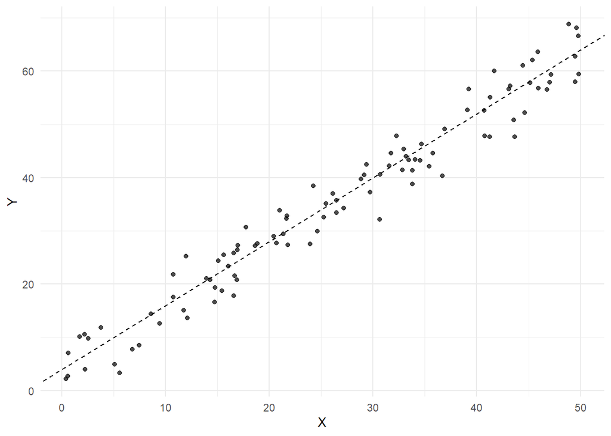

Figure 1.5: Data generated from the simple linear model $Y=4+1.2\times X + \varepsilon$, with $\varepsilon\sim N(0,16)$. Dashed line shows E[Y|X] = β0 + β1X

```r
library(ggplot2)

df <- data.frame(X = X, Y = Y)

ggplot(df, aes(X, Y)) +
  geom_point(alpha = 0.7) +
  geom_abline(intercept = beta_0, slope = beta_1, linetype = "dashed") +
  labs(x = "X", y = "Y") +
  theme_minimal()
```